# Electric Vehicle Pricing

Eric Wilson; Min Thiha Myo; Kevin Maldonado

12/7/2021

# Introduction

Electric Vehicles are rising in popularity amongst consumers in todays day and age. With climate change playing a big factor, several nations have made a consorted effort in investing in ‘green technologies’ which include electric vehicles. The development and improvement of battery technology has made the electric vehicle a viable and perhaps a more preferable choice for consumers. Some of the advantages of electric vehicles include saving money on gas, environmentally friendly, low maintenance cost. Local governments are also offering incentives to buy an electric vehicle. As there is with any new technology, there are challenges that electric vehicles face. Charging station scarcity and battery range are 2 big hurdles that owners will have to face. Despite the challenges that owners and manufactures might have to overcome, the rise of ownership of electric vehicles is undeniable and will only increase heading into the future.

Our project will take data from various electric vehicles that are available in the market and from that data we will perform a regression analysis to predict the price of electric vehicles based on different variables such as battery size, acceleration, range and efficiency.

# Data Preparation

## Data Source

Our data can be found through this link: https://www.kaggle.com/kkhandekar/cheapest-electric-cars

##Loading Dataset Our EV dataset contains 180 observations (rows) and 12 variables (columns).

```r
ev <- read_xlsx('Electric Vehicle Data/Cheapestelectriccars-EVDatabase.xlsx',
                sheet = 'Cheapestelectriccars- UTF8')
```

## Data Cleanup

We now go into our data and start our clean up process. We start by converting several variables to numeric. Battery Size, PriceinUK, Acceleration, Top Speed, Range, Efficiency, Fast charge speed, and Price in Germany all get converted to numeric. Along with this conversion, we perform some regex (regular expression) to our data so that we can perform a successful conversion to numeric. Our ‘Drive’ variable will be converted to a factor. Note that since our data set comes from european sources the units will be in kilometers.

```r
# Convert Character Vectors into useable numeric vectors
ev$BatterySize <- as.numeric(gsub(".* ([0-9]{2,3}[.]*[0-9]*) kWh", "\\1", ev$Subtitle))
libra_strip <- gsub(".([0-9]{2,3},[0-9]{3})", "\\1", ev$PriceinUK) # strip the libra symbol
ev$PriceinUK <- as.numeric(gsub(",", "", libra_strip))
ev$Acceleration <- as.numeric(gsub(" sec", "", ev$Acceleration))
ev$TopSpeed <- as.numeric(gsub(" km/h", "", ev$TopSpeed))
ev$Range <- as.numeric(gsub(" km", "", ev$Range))
ev$Efficiency <- as.numeric(gsub(" Wh/km", "", ev$Efficiency))
ev$FastChargeSpeed <- as.numeric(gsub(" km/h", "", ev$FastChargeSpeed))
ev$Drive <- as.factor(ev$Drive)
ev$PriceinGermany <- as.numeric(ev$PriceinGermany)
ev <- ev[,-2] #removing subtitle column
```

We then check for any missing values in our data set and remove them.

```r
# Limit ev to complete records, German Prices
ev <- ev[complete.cases(cbind(ev$FastChargeSpeed, ev$PriceinGermany)),]
attach(ev)
```

# Exploratory Data Analysis

Let’s to a look at our data set now that we have removed missing values and cleaned it up.

```r
head(ev)
```

```
## # A tibble: 6 x 11
##   Name           Acceleration TopSpeed Range Efficiency FastChargeSpeed Drive
##   <chr>                 <dbl>    <dbl> <dbl>      <dbl>           <dbl> <fct>
## 1 Opel Ampera-e           7.3      150   335        173             210 Front W~
## 2 Nissan Leaf             7.9      144   220        164             230 Front W~
## 3 Porsche Tayca~          2.8      260   390        215             860 All Whe~
## 4 Nissan e-NV20~         14        123   165        218             170 Front W~
## 5 Volkswagen ID~          8.9      160   275        164             260 Rear Wh~
## 6 BMW iX3                 6.8      180   385        192             520 Rear Wh~
## # ... with 4 more variables: NumberofSeats <dbl>, PriceinGermany <dbl>,
## #   PriceinUK <dbl>, BatterySize <dbl>
```

We have data available for EV prices in Germany (in euros) and prices in the UK (pound sterling ), but for the purpose of this report we will only be using prices in Germany as our response variable since it provides more data points.

## Summary of Variables

```r
#summary of Battery Size
summary(BatterySize)
```

```
##    Min. 1st Qu.  Median    Mean 3rd Qu.    Max.
##   23.80   45.00   67.25   66.73   78.05  200.00
```

```r
#summary of EV prices in Germany
summary(PriceinGermany)
```

```
##    Min. 1st Qu.  Median    Mean 3rd Qu.    Max.
##   20490   38750   50890   59645   65096  215000
```

```r
#summary of Top speed
summary(TopSpeed)
```

```
##    Min. 1st Qu.  Median    Mean 3rd Qu.    Max.
##   123.0   150.0   160.0   177.7   200.0   410.0
```

```r
#summary of Battery Range
summary(Range)
```

```
##    Min. 1st Qu.  Median    Mean 3rd Qu.    Max.
##   165.0   270.0   340.0   344.1   400.0   970.0
```

The electric vehicles in our data set range in price from €20,490 to €215,000 with an average price of €59,645. Battery size ranges from 23.8kWh to 200kWh with an average battery size of 66.73kWh The battery range ranges from 165km to 970km Top speed ranges from 123km/h to 410km/h with an average top speed of 177.7km/h

## Correlation

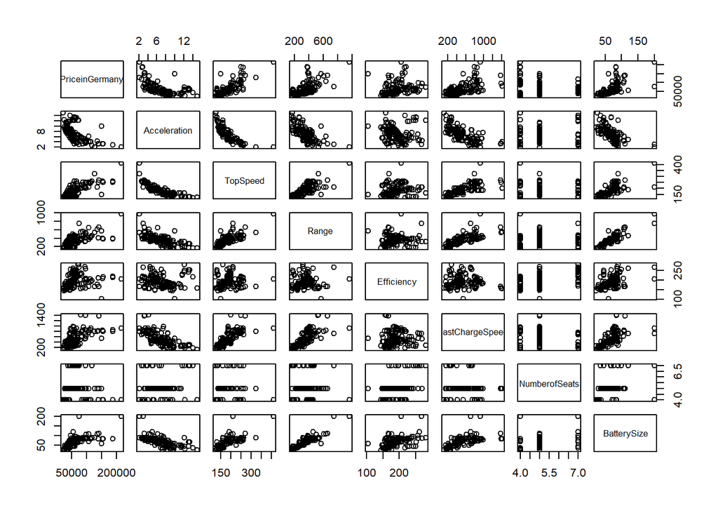

```r
ev_numeric <- ev[, -c(1,7,10 )] #Creating numeric data frame for correlation plots and removing price in UK
pairs(PriceinGermany~., ev_numeric)
```

This scatter plot matrices shows the correlation that exists between variables. Starting from the top left, the variables move downward diagonally and is an axis label for the plots shown. With these scatterplots we can see that there is some correlation between PriceinGermany and top speed, range, fast charging speed and battery size. These plots might be a little difficult to read so lets do a different correlation plot.

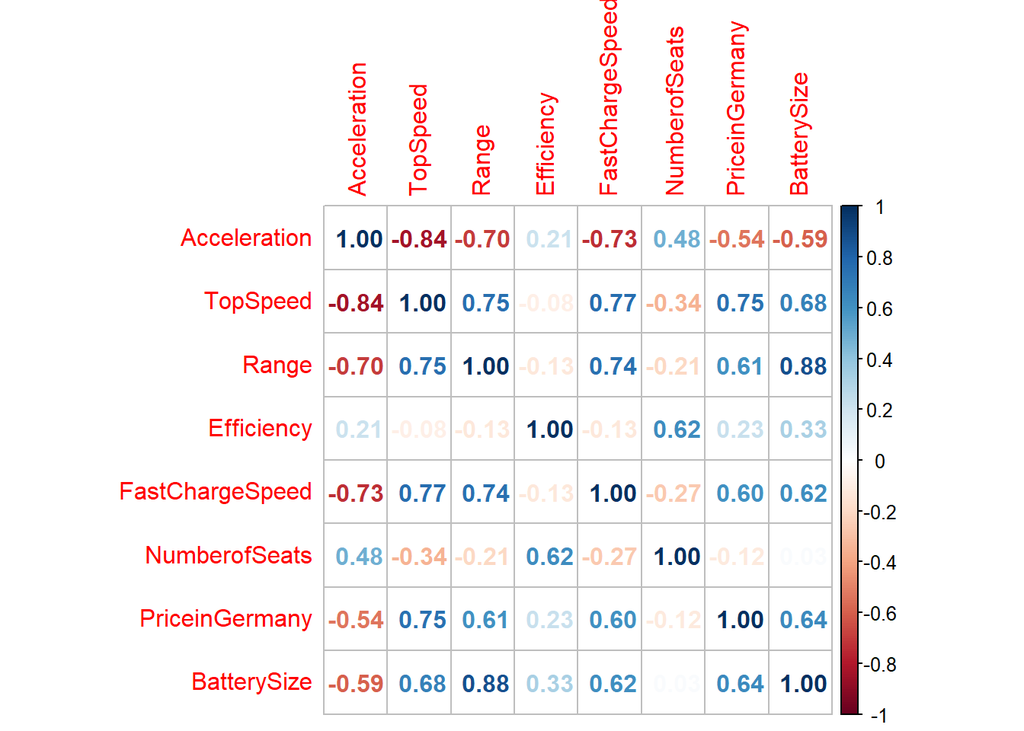

```r
corrplot(cor(ev_numeric), method = "number")
```

This correlation plot is also a correlation matrix. We us the argument “method = number” to show the coefficients in a number with different colors that describe their respective correlation. Confirming with what we saw in the scatterplot matrix, we can easily identify the correlation between PriceinGermany and top speed, range, fast charge speed and battery size.

## Distribution of EV Prices

Taking a more in depth look in EV prices, we will graph the distribution of the prices as well as mark the median and mean

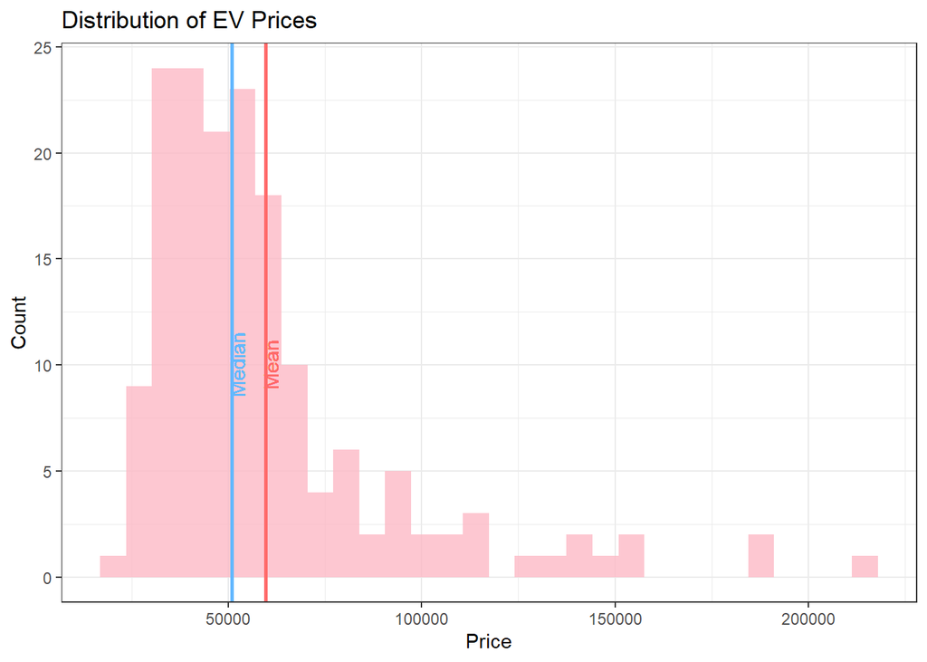

```r
ggplot(ev_numeric, aes(x = PriceinGermany)) +
  geom_histogram(alpha = 0.8,fill = "#fcb9c6") +
  geom_vline(aes(xintercept = mean(PriceinGermany)),col='indianred1',size=1)+ #Vertical Line for Mean
  geom_text(aes(x=mean(PriceinGermany) + 1250, label="Mean", y=10), colour="indianred1", angle=90) +
  geom_vline(aes(xintercept = median(PriceinGermany)),col='steelblue1',size=1)+ #Vertical Line for Median
  geom_text(aes(x=median(PriceinGermany) + 1250, label="Median", y=10), colour="steelblue1", angle=90) +
  labs(x= 'Price',y = 'Count', title = paste("Distribution of EV Prices")) +
  theme_bw()
```

Now we will look at the relationship price has with acceleration, top speed, range and efficiency

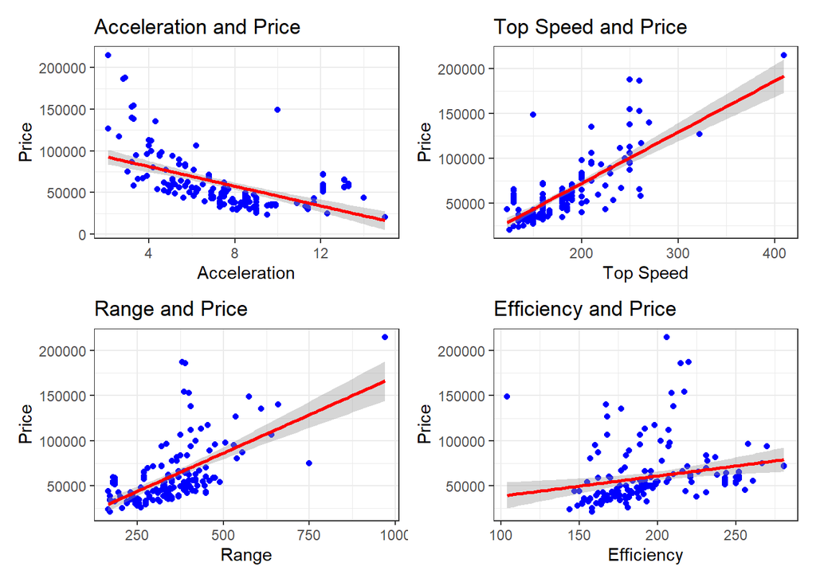

```r
v1 <- ggplot(ev_numeric, aes(x=Acceleration,y=PriceinGermany))+
  geom_point(color = "blue")+

  stat_smooth(aes(x=Acceleration,y=PriceinGermany),method="lm", color="red")+ #code for trend line
  theme_bw()+
  labs(x = 'Acceleration',
       y = 'Price',
       title = 'Acceleration and Price')

v2 <- ggplot(ev_numeric, aes(x=TopSpeed,y=PriceinGermany))+
  geom_point(color = "blue")+

  stat_smooth(aes(x=TopSpeed,y=PriceinGermany),method="lm", color="red")+ #code for trend line
  theme_bw()+
  labs(x = 'Top Speed',
       y = 'Price',
       title = 'Top Speed and Price')


v3 <- ggplot(ev_numeric, aes(x=Range,y=PriceinGermany))+
  geom_point(color = "blue")+

  stat_smooth(aes(x=Range,y=PriceinGermany),method="lm", color="red")+ #code for trend line
  theme_bw()+
  labs(x = 'Range',
       y = 'Price',
       title = 'Range and Price')


v4 <- ggplot(ev_numeric, aes(x=Efficiency,y=PriceinGermany))+
  geom_point(color = "blue")+

  stat_smooth(aes(x=Efficiency,y=PriceinGermany),method="lm", color="red")+ #code for trend line
  theme_bw()+
  labs(x = 'Efficiency',
       y = 'Price',
       title = 'Efficiency and Price')

patch = v1 + v2 + v3 + v4 + plot_layout(ncol=2, nrow=2) #patching all graphs in one frame
patch
```

## Data Transformation

```r
# Transform response and numeric predictors
summary(powerTransform(cbind(ev$PriceinGermany, ev$Acceleration, ev$TopSpeed, ev$Range, ev$Efficiency,
                             ev$FastChargeSpeed, ev$BatterySize)))
```

```
## bcPower Transformations to Multinormality
##    Est Power Rounded Pwr Wald Lwr Bnd Wald Upr Bnd
## Y1   -0.8092        -1.0      -1.0485      -0.5699
## Y2    0.4068         0.5       0.1545       0.6591
## Y3   -1.1500        -1.0      -1.5944      -0.7057
## Y4    0.0030         0.0      -0.0028       0.0089
## Y5    0.0068         0.0      -0.0066       0.0201
## Y6   -0.0498         0.0      -0.2501       0.1505
## Y7    0.0017         0.0      -0.0032       0.0066
##
## Likelihood ratio test that transformation parameters are equal to 0
##  (all log transformations)
##                                        LRT df       pval
## LR test, lambda = (0 0 0 0 0 0 0) 67.80497  7 4.0981e-12
##
## Likelihood ratio test that no transformations are needed
##                                        LRT df       pval
## LR test, lambda = (1 1 1 1 1 1 1) 1710.722  7 < 2.22e-16
```

```r
# Create model with transformed Data
transformed_model <- lm(1/PriceinGermany ~ sqrt(Acceleration) + (1/TopSpeed) + log(Range) +
                 log(Efficiency) + log(FastChargeSpeed) + log(BatterySize), data = ev)
summary(transformed_model)
```

```
##
## Call:
## lm(formula = 1/PriceinGermany ~ sqrt(Acceleration) + (1/TopSpeed) +
##     log(Range) + log(Efficiency) + log(FastChargeSpeed) + log(BatterySize),
##     data = ev)
##
## Residuals:
##        Min         1Q     Median         3Q        Max
## -2.403e-05 -2.714e-06  1.970e-07  2.361e-06  1.395e-05
##
## Coefficients:
##                        Estimate Std. Error t value Pr(>|t|)
## (Intercept)          -5.426e-03  1.645e-03  -3.298 0.001205 **
## sqrt(Acceleration)    3.659e-06  1.066e-06   3.432 0.000766 ***
## log(Range)            8.088e-04  2.380e-04   3.398 0.000860 ***
## log(Efficiency)       7.896e-04  2.380e-04   3.317 0.001129 **
## log(FastChargeSpeed) -3.447e-06  1.387e-06  -2.486 0.013974 *
## log(BatterySize)     -8.158e-04  2.382e-04  -3.425 0.000782 ***
## ---
## Signif. codes:  0 '***' 0.001 '**' 0.01 '*' 0.05 '.' 0.1 ' ' 1
##
## Residual standard error: 4.369e-06 on 158 degrees of freedom
## Multiple R-squared:  0.709,  Adjusted R-squared:  0.6998
## F-statistic: 76.98 on 5 and 158 DF,  p-value: < 2.2e-16
```

## Feature Selection

```r
# Perform Best Subset Selection on Transformed Data
transformed_model_subsets <- regsubsets(x = 1/PriceinGermany ~ sqrt(Acceleration) + (1/TopSpeed)
                             + log(Range) +log(Efficiency) + log(FastChargeSpeed)
                             + log(BatterySize), data = ev)
summary(transformed_model_subsets)
```

```
## Subset selection object
## Call: regsubsets.formula(x = 1/PriceinGermany ~ sqrt(Acceleration) +
##     (1/TopSpeed) + log(Range) + log(Efficiency) + log(FastChargeSpeed) +
##     log(BatterySize), data = ev)
## 5 Variables  (and intercept)
##                      Forced in Forced out
## sqrt(Acceleration)       FALSE      FALSE
## log(Range)               FALSE      FALSE
## log(Efficiency)          FALSE      FALSE
## log(FastChargeSpeed)     FALSE      FALSE
## log(BatterySize)         FALSE      FALSE
## 1 subsets of each size up to 5
## Selection Algorithm: exhaustive
##          sqrt(Acceleration) log(Range) log(Efficiency) log(FastChargeSpeed)
## 1  ( 1 ) " "                " "        " "             " "
## 2  ( 1 ) " "                " "        "*"             "*"
## 3  ( 1 ) "*"                "*"        " "             " "
## 4  ( 1 ) "*"                "*"        "*"             " "
## 5  ( 1 ) "*"                "*"        "*"             "*"
##          log(BatterySize)
## 1  ( 1 ) "*"
## 2  ( 1 ) " "
## 3  ( 1 ) "*"
## 4  ( 1 ) "*"
## 5  ( 1 ) "*"
```

## Best Subset Model

```r
# Create model with transformed Data, without FastChargeSpeed
subset_model <- lm(1/PriceinGermany ~ sqrt(Acceleration) + (1/TopSpeed) + log(Range) +
                 log(Efficiency) + log(BatterySize), data = ev)
summary(subset_model)
```

```
##
## Call:
## lm(formula = 1/PriceinGermany ~ sqrt(Acceleration) + (1/TopSpeed) +
##     log(Range) + log(Efficiency) + log(BatterySize), data = ev)
##
## Residuals:
##        Min         1Q     Median         3Q        Max
## -2.387e-05 -2.973e-06  3.972e-07  2.391e-06  1.341e-05
##
## Coefficients:
##                      Estimate Std. Error t value Pr(>|t|)
## (Intercept)        -6.045e-03  1.653e-03  -3.658 0.000346 ***
## sqrt(Acceleration)  4.915e-06  9.541e-07   5.152 7.54e-07 ***
## log(Range)          8.949e-04  2.393e-04   3.739 0.000257 ***
## log(Efficiency)     8.778e-04  2.392e-04   3.670 0.000330 ***
## log(BatterySize)   -9.046e-04  2.393e-04  -3.781 0.000221 ***
## ---
## Signif. codes:  0 '***' 0.001 '**' 0.01 '*' 0.05 '.' 0.1 ' ' 1
##
## Residual standard error: 4.439e-06 on 159 degrees of freedom
## Multiple R-squared:  0.6976, Adjusted R-squared:   0.69
## F-statistic:  91.7 on 4 and 159 DF,  p-value: < 2.2e-16
```

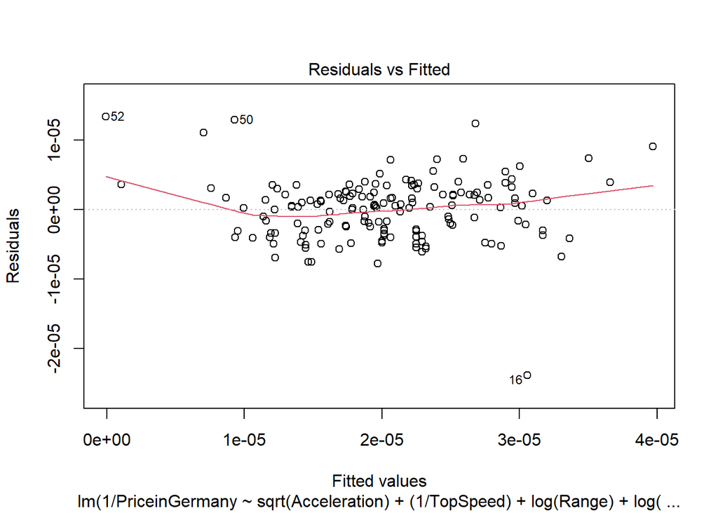

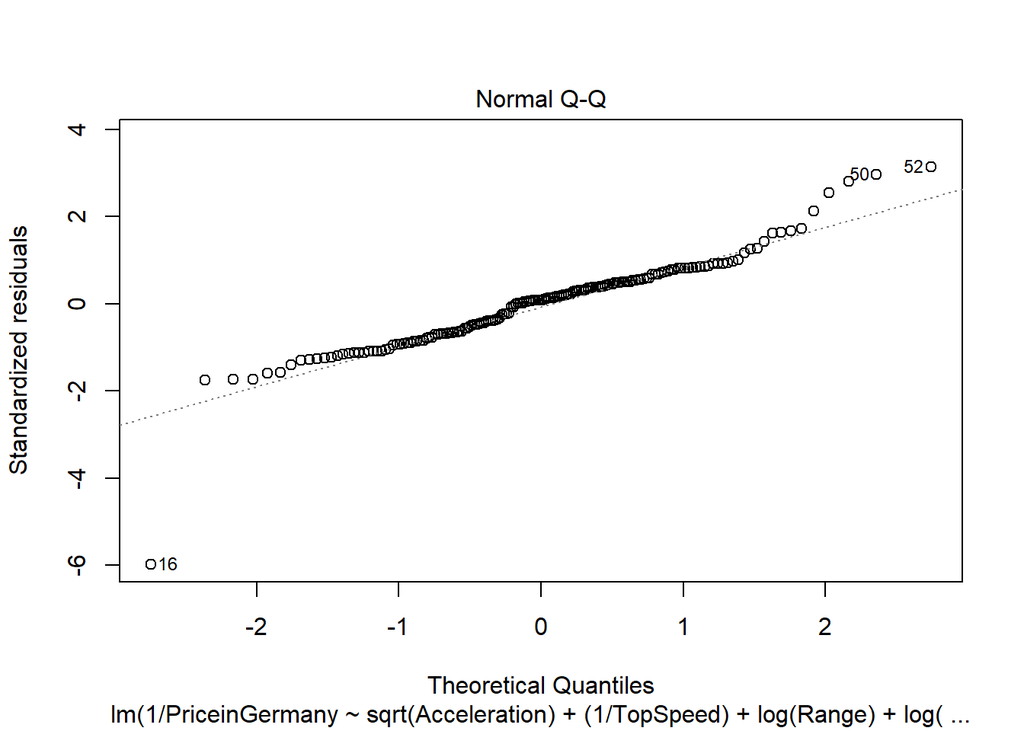

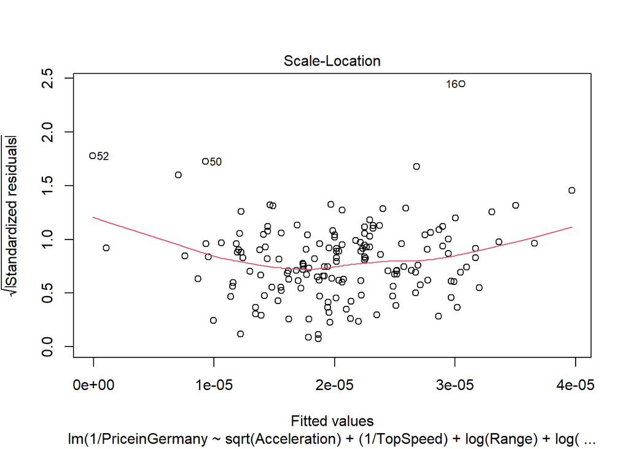

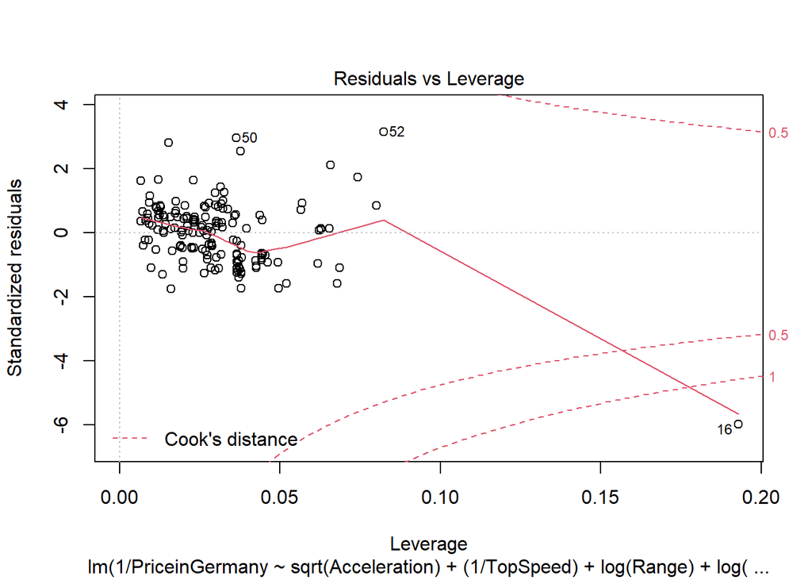

```r
plot(subset_model)
```

In this model, Normal Q-Q is close to linear, and variance is close to constant. We can reasonably make predictions with this model. An outlier is clearly seen with the Lightyear One car, which at the time of this project has not come to market but is priced at 149,000 Euros.